# Lab 7 Part B

## 2. Experiments with classifiers

```python
#1 import required modules
import time
import io
import matplotlib.pyplot as plt
import numpy as np
from scipy.io.arff import loadarff

from sklearn.datasets import get_data_home
from sklearn.externals.joblib import Memory
from sklearn.linear_model import LogisticRegression
from sklearn.model_selection import train_test_split
from sklearn.preprocessing import StandardScaler
from sklearn.utils import check_random_state
from urllib.request import urlopen
```

```python
#2.  read the NMIST dataset
memory = Memory(get_data_home())
@memory.cache()
def fetch_mnist():
    content = urlopen(
        'https://www.openml.org/data/download/52667/mnist_784.arff').read()
    data, meta = loadarff(io.StringIO(content.decode('utf8')))
    data = data.view([('pixels', '<f8', 784), ('class', '|S1')])
    return data['pixels'], data['class']
X, y = fetch_mnist()
```

```python
# rescale the data, use the traditional train/test split

X = X / 255.

X_train, X_test = X[:16000], X[16000:20000]
y_train, y_test = y[:16000], y[16000:20000]
```

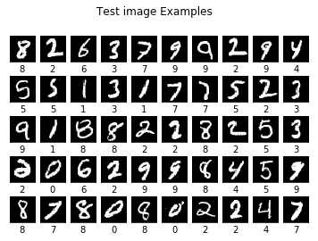

```python
### Bounus 1: show the first 40 images
### ALways a good idea to validate that the data appears as you expect
###
### for sci-kit learn the images are represented as vectors of 784 elements
### currently scaled from 0 to 1

for i in range(50):
    l1_plot = plt.subplot(5, 10, i + 1)
    l1_plot.imshow(255 * X_test[i].reshape(28, 28), interpolation='nearest',
                   cmap=plt.cm.gray)
    l1_plot.set_xticks(())
    l1_plot.set_yticks(())
    #l1_plot.set_xlabel('Class %s' % y_test[i].decode())
    l1_plot.set_xlabel('%i' % int(y_test[i]))
plt.suptitle('Test image Examples')
plt.show()
```

### 1. Evaluate a K-nearest-neighbor (K-NN) classifier for 1 and 3 near neighbors. Also, select a number of near neighbors for an additional test.

```python
from sklearn.neighbors import KNeighborsClassifier
from sklearn.neural_network import MLPClassifier
from sklearn.svm import SVC
```

```python
start_time = time.time()
#Classifier Declaration
KNN = KNeighborsClassifier(n_neighbors=3)
#Train the classifier
KNN.fit(X_train,y_train)
train_time = time.time() - start_time
start_time = time.time()
print("Training time %.3f seconds" % train_time)
#Evaluate the result
score = KNN.score(X_test,y_test)
print("Test score with 3NN is: %.4f" % score)
test_time = time.time() - start_time
print("Test time %.3f seconds" % test_time)
print("Test score with 3NN is: %.4f" % score)
```

```
Training time 0.578 seconds
Test score with 3NN is: 0.9540
Test time 75.919 seconds
Test score with 3NN is: 0.9540
```

```python
start_time = time.time()
#Classifier Declaration
KNN = KNeighborsClassifier(n_neighbors=1)
#Train the classifier
KNN.fit(X_train,y_train)
train_time = time.time() - start_time
start_time = time.time()
print("Training time %.3f seconds" % train_time)
#Evaluate the result
score = KNN.score(X_test,y_test)
print("Test score with 3NN is: %.4f" % score)
test_time = time.time() - start_time
print("Test time %.3f seconds" % test_time)
print("Test score with 3NN is: %.4f" % score)
```

```
Training time 0.581 seconds
Test score with 3NN is: 0.9555
Test time 76.857 seconds
Test score with 3NN is: 0.9555
```

I selected 2 and 4 near neighbors for additional tests.

```python
start_time = time.time()
#Classifier Declaration
KNN = KNeighborsClassifier(n_neighbors=2)
#Train the classifier
KNN.fit(X_train,y_train)
train_time = time.time() - start_time
start_time = time.time()
print("Training time %.3f seconds" % train_time)
#Evaluate the result
score = KNN.score(X_test,y_test)
print("Test score with 3NN is: %.4f" % score)
test_time = time.time() - start_time
print("Test time %.3f seconds" % test_time)
print("Test score with 3NN is: %.4f" % score)
```

```
Training time 0.583 seconds
Test score with 3NN is: 0.9487
Test time 75.991 seconds
Test score with 3NN is: 0.9487
```

```python
start_time = time.time()
#Classifier Declaration
KNN = KNeighborsClassifier(n_neighbors=4)
#Train the classifier
KNN.fit(X_train,y_train)
train_time = time.time() - start_time
start_time = time.time()
print("Training time %.3f seconds" % train_time)
#Evaluate the result
score = KNN.score(X_test,y_test)
print("Test score with 3NN is: %.4f" % score)
test_time = time.time() - start_time
print("Test time %.3f seconds" % test_time)
print("Test score with 3NN is: %.4f" % score)
```

```
Training time 0.583 seconds
Test score with 3NN is: 0.9543
Test time 77.787 seconds
Test score with 3NN is: 0.9543
```

I reduced the size of the training dataset to 16000 and the testing dataset to 4000, the total size is 20000. When reducing the size of the dataset, the accuracy would reduced,too. That is because the reduction of the training data would not make it not comprehensive enough for the classifier to produce high accuracy compared to the whole dataset. However, it is not a good idea to have a huge dataset.